# Atividade Prática 2

Flavio Barbosa Shirahige

2023-11-07

```r
knitr::opts_chunk$set(echo = TRUE)
library(tidyverse)
library(readxl)
library(stringi)
library(factoextra)
library(ggrepel)
library(dplyr)
```

# Base de dados

Os dados que serão utilizados nessa atividade são Secretaria de Segurança Pública de São Paulo e se referem à produtividade policial, registrados por mês ao longo de 2021 e detalhados para cada uma das regiões do estado de São Paulo.

O primeiro passo é importar a base de dados e explorar a base importada:

```r
dados <- read_xlsx("produtividade_policial.xlsx")

dados %>%
  sample_n(10)
```

```
## # A tibble: 10 × 15
##    Região Ocorrencia   Jan   Fev   Mar   Abr   Mai   Jun   Jul   Ago   Set   Out
##    <chr>  <chr>      <dbl> <dbl> <dbl> <dbl> <dbl> <dbl> <dbl> <dbl> <dbl> <dbl>
##  1 Capit… TOT. DE I…  6738  7746  8087  7289  7334  7815  7219  7435  7698  7607
##  2 Pirac… OCORRÊNCI…    34    22    37    28    29    22    24    28    24    22
##  3 Bauru  Nº DE FLA…   379   342   400   384   387   385   342   417   372   328
##  4 Grand… Nº DE PRI…  1849  1906  2014  1805  2065  2068  1977  2063  1868  1901
##  5 Ribei… Nº DE PRI…  1153  1250  1286  1196  1167  1259  1169  1274  1206  1133
##  6 São J… Nº DE PES…   328   372   337   325   355   299   337   361   358   343
##  7 São J… Nº DE VEÍ…    99   124   118   108   119    95    77    95   113    85
##  8 Araça… OCORRÊNCI…    34    30    30    25    39    49    28    28    46    32
##  9 Pirac… Nº DE PRI…   928   921  1033   963  1052   955   972   980   997   882
## 10 Araça… OCORRÊNCI…    83    74    96   108   120   116    74    95    69    86
## # ℹ 3 more variables: Nov <dbl>, Dez <dbl>, Total <dbl>
```

Para facilitar a manipulação dos dados, serão removidos os caracteres especiais do nome das columas e deixá-los em letras minúsuculas:

```r
dados <- dados %>%
  rename_with(~ stri_trans_general(.x, "Latin-ASCII") %>%
                tolower())

dados %>%
  sample_n(10)
```

```
## # A tibble: 10 × 15
##    regiao ocorrencia   jan   fev   mar   abr   mai   jun   jul   ago   set   out
##    <chr>  <chr>      <dbl> <dbl> <dbl> <dbl> <dbl> <dbl> <dbl> <dbl> <dbl> <dbl>
##  1 Grand… Nº DE VEÍ…   845   690   678   699   853   801   785   833   853   897
##  2 Campi… OCORRÊNCI…    99   121   121    74   101   119    97   106    93   114
##  3 São J… OCORRÊNCI…     9     4     4     9    11     3     3     7     7     5
##  4 Campi… OCORRÊNCI…   311   313   321   305   306   316   277   310   262   285
##  5 Santos OCORRÊNCI…    29    13    25    29    38    27    29    21    23    16
##  6 Campi… Nº DE INF…     9    10     7    11    10    12     4    19    10     9
##  7 Campi… Nº DE PES…   282   314   300   295   378   320   314   331   300   286
##  8 Grand… OCORRÊNCI…   444   509   544   531   612   534   484   535   477   459
##  9 Presi… Nº DE PRI…   423   406   451   395   506   465   480   496   466   471
## 10 São J… Nº DE INF…    44    65    40    63    54    46    44    55    34    46
## # ℹ 3 more variables: nov <dbl>, dez <dbl>, total <dbl>
```

## Tarefa 1

Pergunta: “Para este exercício, manipule os dados para considerar apenas os dados totais de cada indicador para cada região. Forneça o código que deixa os dados no seguinte formato:”

Assim, vamos manipular os dados para considerar apenas os dados totais de cada indicador para cada região:

```r
dados <- subset(dados, select = c(regiao, ocorrencia, total))
```

E colocar a tabela no formato em que a coluna de ocorrências se transforme em 1 coluna por indicador:

```r
dados <- dados %>% pivot_wider(names_from = ocorrencia,
                               values_from = total)
dados %>%
  sample_n(10)
```

```
## # A tibble: 10 × 14
##    regiao   OCORRÊNCIAS DE PORTE…¹ OCORRÊNCIAS DE TRÁFI…² OCORRÊNCIAS DE APREE…³
##    <chr>                     <dbl>                  <dbl>                  <dbl>
##  1 Campinas                   1260                   3502                    741
##  2 Preside…                    652                   1506                    217
##  3 São Jos…                    627                   2356                     92
##  4 Araçatu…                    394                   1089                     34
##  5 Sorocaba                   1085                   3010                    447
##  6 Santos                     1322                   2013                    319
##  7 Piracic…                   1566                   4818                    748
##  8 São Jos…                    678                   1997                     82
##  9 Ribeirã…                   3208                   4284                    581
## 10 Capital                    1587                   6237                    483
## # ℹ abbreviated names: ¹`OCORRÊNCIAS DE PORTE DE ENTORPECENTES`,
## #   ²`OCORRÊNCIAS DE TRÁFICO DE ENTORPECENTES`,
## #   ³`OCORRÊNCIAS DE APREENSÃO DE ENTORPECENTES(1)`
## # ℹ 10 more variables: `OCORRÊNCIAS DE PORTE ILEGAL DE ARMA` <dbl>,
## #   `Nº DE ARMAS DE FOGO APREENDIDAS` <dbl>, `Nº DE FLAGRANTES LAVRADOS` <dbl>,
## #   `Nº DE INFRATORES APREENDIDOS EM FLAGRANTE` <dbl>,
## #   `Nº DE INFRATORES APREENDIDOS POR MANDADO` <dbl>, …
```

## Tarefa 2

Pergunta: “Realize o procedimento para obter as componentes principais deste conjunto de dados. Quantas componentes principais são necessárias para se explicar pelo menos 80% da variância dos dados?”

O primeiro passo é obter as compomentes por meio da função prcomp e plotado o gráfico da variância dos dados explicada pelas componentes:

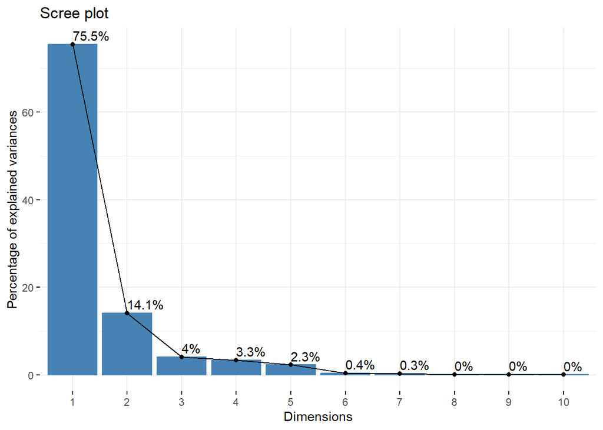

```r
set.seed(123)
dados <- dados %>%
  column_to_rownames(var = "regiao")
X <- scale(dados, center = TRUE, scale = TRUE)
pca <- prcomp(X)
pca$rotation <- -pca$rotation #contribuição de cada uma das preditoras para cada uma das componentes (invertendo o sinal)
pca$x <- -pca$x #valores das componentes para cada observação/cidade (invertendo o sinal)
Phi <- pca$rotation #contribuição de cada uma das preditoras para cada uma das componentes com sinal invertido
dados_pca <- pca$x #valores das componentes para cada observação/cidade com sinal investido
fviz_eig(pca, addlabels = TRUE)
```

E abaixo a soma acumulada do percentual explicado da variância dos dados:

```r
(cumsum(pca$sdev^2) / sum(pca$sdev^2))
```

```
##  [1] 0.7549993 0.8956493 0.9361194 0.9694455 0.9921333 0.9960966 0.9990281
##  [8] 0.9995060 0.9998647 0.9999823 1.0000000 1.0000000
```

Assim, com duas componentes principais podemos explicar mais de 80% da variância dos dados.

## Tarefa 3

Pergunta: “Obtenha as contribuições das preditoras para a primeira componente principal. Qual nome você daria para esta componente?”

```r
Phi[1:13,1:1]
```

```
##        OCORRÊNCIAS DE PORTE DE ENTORPECENTES
##                                  -0.13833778
##      OCORRÊNCIAS DE TRÁFICO DE ENTORPECENTES
##                                  -0.30075608
## OCORRÊNCIAS DE APREENSÃO DE ENTORPECENTES(1)
##                                  -0.19250048
##          OCORRÊNCIAS DE PORTE ILEGAL DE ARMA
##                                  -0.30456636
##              Nº DE ARMAS DE FOGO APREENDIDAS
##                                  -0.30907214
##                    Nº DE FLAGRANTES LAVRADOS
##                                  -0.31438592
##    Nº DE INFRATORES APREENDIDOS EM FLAGRANTE
##                                  -0.31208691
##     Nº DE INFRATORES APREENDIDOS POR MANDADO
##                                  -0.07876142
##            Nº DE PESSOAS PRESAS EM FLAGRANTE
##                                  -0.31404928
##             Nº DE PESSOAS PRESAS POR MANDADO
##                                  -0.27090893
##                      Nº DE PRISÕES EFETUADAS
##                                  -0.31626933
##                   Nº DE VEÍCULOS RECUPERADOS
##                                  -0.30475943
##     TOT. DE INQUÉRITOS POLICIAIS INSTAURADOS
##                                  -0.31257390
```

Esta componente será nomeada como “Flagrante”.

## Tarefa 4

Pergunta: “Obtenha as contribuições das preditoras para a segunda componente principal. Qual nome você daria para esta componente?”

```r
Phi[1:13,2:2]
```

```
##        OCORRÊNCIAS DE PORTE DE ENTORPECENTES
##                                   0.53050880
##      OCORRÊNCIAS DE TRÁFICO DE ENTORPECENTES
##                                   0.17446019
## OCORRÊNCIAS DE APREENSÃO DE ENTORPECENTES(1)
##                                   0.40149073
##          OCORRÊNCIAS DE PORTE ILEGAL DE ARMA
##                                  -0.04847191
##              Nº DE ARMAS DE FOGO APREENDIDAS
##                                  -0.13978136
##                    Nº DE FLAGRANTES LAVRADOS
##                                  -0.11472248
##    Nº DE INFRATORES APREENDIDOS EM FLAGRANTE
##                                  -0.09326308
##     Nº DE INFRATORES APREENDIDOS POR MANDADO
##                                   0.64030319
##            Nº DE PESSOAS PRESAS EM FLAGRANTE
##                                  -0.12169285
##             Nº DE PESSOAS PRESAS POR MANDADO
##                                   0.05400083
##                      Nº DE PRISÕES EFETUADAS
##                                  -0.01820446
##                   Nº DE VEÍCULOS RECUPERADOS
##                                  -0.18950150
##     TOT. DE INQUÉRITOS POLICIAIS INSTAURADOS
##                                  -0.13865788
```

Esta componente será nomeada como “Baixo Risco de Morte do Policial”, pois os crimes envolvidos nessa componente tem baixo risco de confronto.

## Tarefa 5

Pergunta: “Faça um gráfico de dispersão com as duas primeiras componentes principais. Com base nas respostas anteriores e neste gráfico, o que pode-se dizer sobre a Capital? E sobre a região de Ribeirão Preto? E Sorocaba?”

RIbeirão Preto e Piraciba são cidades onde as ocorrências policiais têm um tendência de risco menor de morte do policial, enquanto as cidades da Grande São Paulo têm predominância de ocorrências policiais com Flagrante. No entanto, a Capital (sem as demais cidades da Grande São Paulo) possui baixa propensão de ocorrências com risco menor de morte do policial.

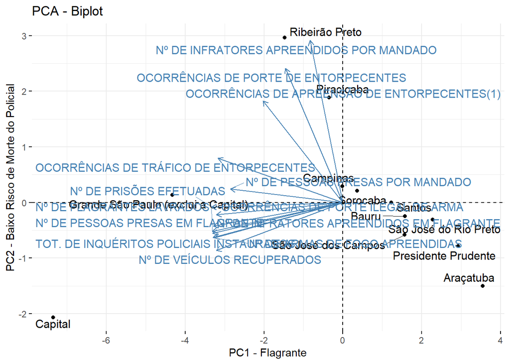

```r
fviz_pca_biplot(pca, repel = TRUE, xlab = "PC1 - Flagrante", ylab = "PC2 - Baixo Risco de Morte do Policial")
```

## Tarefa 6 - Análise de Conglomerados

### Tarefa 6.1

Pergunta: “Execute o método k-means para identificar o número ótimo de clusters entre as regiões analisada.”

Inicialmente, faremos o gráfico do Método Silhouette:

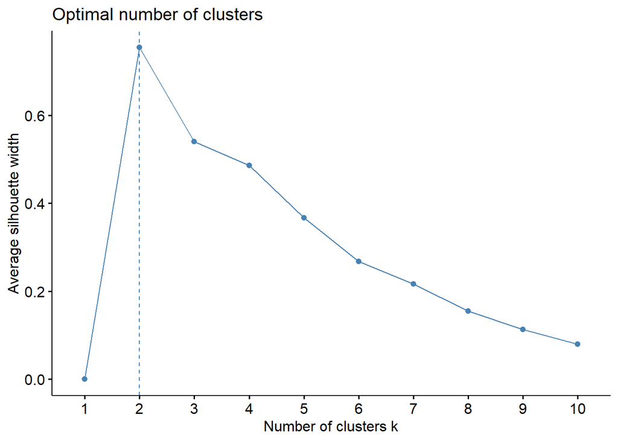

```r
fviz_nbclust(dados, kmeans, method = "silhouette")
```

Pelo método Silhouette, o número ótimo de clusters é 2.

Abaixo, vamos plotar o gráfico do Método do Cotovelo para verificar o número de cluster que minimiza a distância dos pontos dentro do cluster, iterando para até 10 clusters:

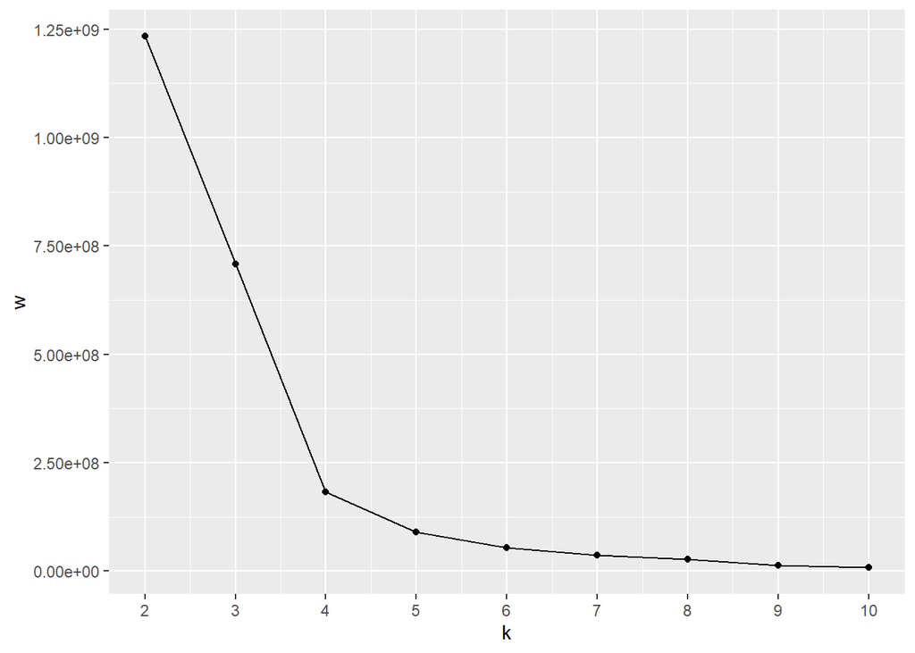

```r
set.seed(123)
k <- 2:10
tibble(k = k) %>%
  mutate(w = map_dbl(k, ~ kmeans(dados, centers = .x,
                                 nstart = 10)$tot.withinss)) %>%
  ggplot(aes(k, w)) +
  geom_point() +
  scale_x_continuous(breaks = k) +
  geom_line()
```

Pela análise acima, 4 clusters configura um ponto ótimo entre a minimização da distância dentro do cluster e o número de clusters que permite a interpretabilidade (quanto menor o número de clusters, melhor).

### Tarefa 6.2

Pergunta: “Visualize os grupos obtidos em um gráfico de dispersão (utilize o resultado do PCA para a construção dos gráficos).”

Inicialmente vamos converter a matriz dados_pca (que possui os valores das componentes para cada observação) em uma dataframe (tabela). Na sequência, vamos construir o gráfico de dispersão com as componentes “PC1 - Alta Periculosidade” e “PC2 - Baixa Periculosidade”.

```r
set.seed(123)
dados_pca <- as.data.frame(dados_pca)
(descricao <- dados_pca %>%
    mutate(cluster = factor(kmeans(dados, centers = 4, nstart = 10)$cluster)))
```

```
##                                             PC1          PC2        PC3
## Capital                             -7.34644189 -2.063506708 -0.6187202
## Grande São Paulo (exclui a Capital) -4.32521997  0.134200537  0.9648500
## São José dos Campos                  1.56918050 -0.583710057 -0.6949921
## Campinas                            -0.01074086  0.288051746  0.9464465
## Ribeirão Preto                      -1.47338587  2.965174636 -1.2901226
## Bauru                                1.57872889 -0.245366941  0.6048001
## São José do Rio Preto                2.28086760 -0.306725391 -0.3776616
## Santos                               1.23430431 -0.001962707 -0.4338570
## Sorocaba                             0.36313204  0.210061380  0.2914772
## Presidente Prudente                  2.92543574 -0.782649144  0.1335627
## Piracicaba                          -0.34886691  1.886631201  0.7462304
## Araçatuba                            3.55300642 -1.500198551 -0.2720132
##                                            PC4         PC5         PC6
## Capital                              0.4738965  0.19587033  0.11070092
## Grande São Paulo (exclui a Capital) -1.0546632 -0.47070517 -0.03756386
## São José dos Campos                 -1.1612857  0.09193841 -0.40318533
## Campinas                             0.4124966  0.98455667 -0.10508611
## Ribeirão Preto                       0.3589350  0.07046946  0.02721310
## Bauru                                0.8881308 -0.43301487 -0.22577895
## São José do Rio Preto               -0.3488113 -0.80365896  0.32328957
## Santos                               0.1248925  0.29007287 -0.20496471
## Sorocaba                             0.6857319 -0.83228838 -0.15941008
## Presidente Prudente                  0.3294916  0.03996068  0.24807078
## Piracicaba                          -0.4664874  0.34922129  0.25358926
## Araçatuba                           -0.2423274  0.51757767  0.17312541
##                                             PC7         PC8          PC9
## Capital                             -0.12541937  0.03666183  0.002405625
## Grande São Paulo (exclui a Capital)  0.30997823 -0.05425099 -0.005569111
## São José dos Campos                 -0.24739200 -0.00771358  0.035140340
## Campinas                            -0.06623292 -0.08372216  0.086823418
## Ribeirão Preto                       0.10917925 -0.06677198  0.020683563
## Bauru                                0.05964987  0.09033240  0.063174273
## São José do Rio Preto               -0.05431091  0.02671487  0.098657934
## Santos                               0.30206676  0.12992046 -0.057458122
## Sorocaba                            -0.21802272 -0.08480650 -0.115227838
## Presidente Prudente                  0.09146906 -0.04242068  0.018981463
## Piracicaba                          -0.25835023  0.11806329 -0.058123301
## Araçatuba                            0.09738498 -0.06200695 -0.089488244
##                                             PC10          PC11          PC12
```

[output cut: 10 more lines]

```
## Piracicaba                          -0.015833140 -0.0020631233  0.000000e+00
## Araçatuba                            0.009755877 -0.0269402191  1.110223e-16
##                                     cluster
## Capital                                   3
## Grande São Paulo (exclui a Capital)       4
## São José dos Campos                       1
## Campinas                                  2
## Ribeirão Preto                            2
## Bauru                                     1
## São José do Rio Preto                     1
## Santos                                    1
## Sorocaba                                  2
## Presidente Prudente                       1
## Piracicaba                                2
## Araçatuba                                 1
```

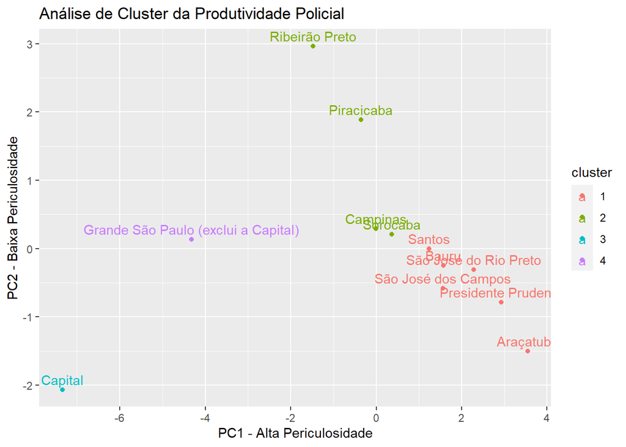

```r
descricao %>%
  ggplot(aes(PC1, PC2, color = cluster)) +
  geom_point()+geom_text(aes(label = row.names(dados_pca)), vjust = -0.5) +
  labs(
    x = "PC1 - Alta Periculosidade",
    y = "PC2 - Baixa Periculosidade",
    title = "Análise de Cluster da Produtividade Policial"
  )
```

### Tarefa 6.3

Pergunta: “Analise os resultados dos métodos de clusterização e interprete os grupos obtidos”

Conforme o gráfico acima, foram definidos 4 clusters. Assim, temos:

- Cluster 1 - regiões com menor predominância nas duas componentes;
- Cluster 2 - regiões com maior predominância de ocorrências de baixo risco de morte;
- Cluster 3 - regiões comlto número de ocorrências de Flagrante, sem predominância de ocorrências de baixo risco de morte;
- Cluster 4 - regiões com predominância de Flagrante, mas com risco de morte moderado.

### Tarefa 6.4

Pergunta: “Discuta as implicações práticas dos grupos identificados, considerando possíveis ações que a Secretaria de Segurança Pública de São Paulo pode realizar”

Resposta: A Secretaria de Segurança Pública pode definir a distribuição de verbas e recursos com base na mitigição dos riscos relacionados às caracterísicas das ocorrências de cada cluster, conforme discutido no item anterior. Por exemplo, alocar para as regiões do cluster 3 um maior volume de recursos para compra de equipamentos de segurança por ter ocorrências de maior risco (flagrante).